# stm_scaling_r.Rmd

2024-12-02

```r
# install.packages("tm")
# install.packages("tidyverse")
# install.packages("ggthemes")
# install.packages("ggrepel")
# install.packages("cowplot")
# install.packages("quanteda")
# install.packages("quanteda.textmodels")



# install.packages(quanteda.textplots)
# install.packages("gtools")
# install.packages("sotu")
# install.packages("stm")
# install.packages(c("Rtsne", "rsvd", "geometry", "purrr"))
```

Note: you only need to install the packages once.

We then need load the packages in our environment:

```r
library(tm)
library(tidyverse)
library(ggthemes)
library(ggrepel)
library(quanteda)
library(quanteda.textmodels)
library(gtools)
library(sotu)
library(stm)
library(purrr)
library(quanteda.textplots)
```

# Topic Modeling

We will be using the `stm` package and `sotu` data.

First, let’s load up the data:

```r
sotu <- sotu_text %>% as_tibble()
sotu_metadata <- sotu_meta %>% as_tibble()




sotu <- bind_cols(sotu, sotu_metadata)

summary(sotu)
```

```
##     value                 X           president              year
##  Length:240         Min.   :  1.00   Length:240         Min.   :1790
##  Class :character   1st Qu.: 60.75   Class :character   1st Qu.:1849
##  Mode  :character   Median :120.50   Mode  :character   Median :1908
##                     Mean   :120.50                      Mean   :1907
##                     3rd Qu.:180.25                      3rd Qu.:1965
##                     Max.   :240.00                      Max.   :2020
##  years_active          party            sotu_type
##  Length:240         Length:240         Length:240
##  Class :character   Class :character   Class :character
##  Mode  :character   Mode  :character   Mode  :character
##
##
##
```

Let’s inspect a text:

```r
sotu$value[1]
```

```
## [1] "Fellow-Citizens of the Senate and House of Representatives: \n\nI embrace with great satisfaction the opportunity which now presents itself of congratulating you on the present favorable prospects of our public affairs. The recent accession of the important state of North Carolina to the Con…
```

Also, the timeframe in the dataset is quite large (1790 to 2020). We might want to trim it, since the language might have changed significantly in this time.

```r
sotu <- sotu %>%
  filter(year >= 1901)
```

Ok, we need to do basic preprocessing. We can do that immediately within the infrastructure of the `stm` package, with the `textProcessor` function.

This will take a few seconds…

```r
sotu_data <- textProcessor(
  sotu$value,
  metadata = sotu
)
```

```
## Building corpus...
## Converting to Lower Case...
## Removing punctuation...
## Removing stopwords...
## Removing numbers...
## Stemming...
## Creating Output...
```

Ok, now we have the processed object.

```r
sotu_data
```

```
## A text corpus with 128 documents, and an 15407 word dictionary.
```

Next, we need to prepare the documents for topic modeling. This is done with the `prepDocuments` function

```r
sotu_data_prepd <- prepDocuments(sotu_data$documents,
                                 sotu_data$vocab,
                                 sotu_data$meta)
```

```
## Removing 7393 of 15407 terms (7393 of 157453 tokens) due to frequency
## Your corpus now has 128 documents, 8014 terms and 150060 tokens.
```

Now we’re ready for some modelling! This will also take some time.

```r
sotu_topic_10 <- stm(documents = sotu_data_prepd$documents,
                     sotu_data_prepd$vocab,
                     K = 10,
                     max.em.its = 75,
                     data = sotu_data_prepd$meta,
                     init.type = "Spectral")
```

When the model is done running, we can inspect the output. Different possible ways to do so:

```r
labelTopics(sotu_topic_10)
```

```
## Topic 1 Top Words:
##       Highest Prob: will, nation, year, govern, program, must, state
##       FREX: dollar, fiscal, expenditur, estim, price, wage, veteran
##       Lift: -cent, antimonopoli, multiple-purpos, mustering-, nuclear-pow, reinsur, smile
##       Score: reconvers, lend-leas, atom, communist, demobil, shall, prewar
## Topic 2 Top Words:
##       Highest Prob: govern, state, unit, will, year, depart, congress
##       FREX: canal, panama, appoint, arbitr, statut, tariff, court
##       Lift: -mention, abstain, adjut, alsop, amiabl, apportion, assuag
##       Score: isthmus, wool, arbitr, post-offic, consular, hagu, opium
## Topic 3 Top Words:
##       Highest Prob: will, american, year, america, peopl, work, new
##       FREX: terrorist, kid, that, iraqi, thank, qaida, iraq
##       Lift: kid, qaida, ---, -school, abstin, airmen, al-baghdadi
##       Score: tonight, that, weve, terrorist, iraq, kid, dont
## Topic 4 Top Words:
##       Highest Prob: will, year, america, can, american, peopl, govern
##       FREX: spend, let, weve, america, speaker, truli, ive
##       Lift: baker, freshmen, itll, peoplethos, risktak, russel, schoolroom
##       Score: weve, tonight, ive, there, soviet, sandinista, laughter
## Topic 5 Top Words:
##       Highest Prob: nation, will, world, war, must, peopl, peac
##       FREX: enemi, victori, fight, war, german, democraci, ruler
##       Lift: hitler, -inclus, -produc, againth, aluminum, amphibi, anotherwil
##       Score: soviet, communist, nazi, hitler, fascist, french, tank
## Topic 6 Top Words:
##       Highest Prob: will, year, program, feder, nation, new, congress
##       FREX: environment, rural, reform, ensur, energi, signific, administr
##       Lift: -fault, anomali, auster, billon, bonn, breakfast, brezhnev
##       Score: environment, nuclear, privaci, sector, solar, reactor, regulatori
## Topic 7 Top Words:
##       Highest Prob: govern, will, nation, congress, countri, can, year
##       FREX: relief, agricultur, debt, board, depress, method, bank
##       Lift: bitumin, extraterritori, freight-rat, intracoast, prostrat, self-liquid, shoal
##       Score: tile, nitrat, shoal, tribun, reclam, undoubt, valuat
## Topic 8 Top Words:
##       Highest Prob: nation, will, law, govern, state, can, upon
##       FREX: forest, wage-work, interst, man, island, supervis, mere
##       Lift: -capit, abomin, acquit, adulter, amplest, anarchist, annal
##       Score: wage-work, exposit, injunct, anarchist, wagework, hagu, wrongdo
## Topic 9 Top Words:
##       Highest Prob: will, nation, year, congress, program, continu, state
##       FREX: refuge, oil, region, soviet, afghanistan, implement, energi
##       Lift: --pocket, -ship, alternativesprogram, andean, areath, billsth, brooke-cranston
##       Score: nuclear, soviet, afghanistan, solar, persian, reauthor, gasohol
## Topic 10 Top Words:
##       Highest Prob: will, nation, year, must, new, can, american
##       FREX: vietnam, poverti, communist, allianc, test, south, tonight
##       Lift: abroad-, alliesand, anti-guerrilla, battleth, causesth, courthous, departmenta
##       Score: tonight, vietnam, communist, nuclear, viet-nam, soviet, pinpoint
```

First, we might want to remove these terms.

```r
sotu_data <- textProcessor(
  sotu$value,
  metadata = sotu,
  customstopwords = c("will",
                      "national",
                      "nation",
                      "year",
                      "america",
                      "american",
                      "government",
                      "govern",
                      "can",
                      "must")
)
```

```
## Building corpus...
## Converting to Lower Case...
## Removing punctuation...
## Removing stopwords...
## Remove Custom Stopwords...
## Removing numbers...
## Stemming...
## Creating Output...
```

```r
sotu_data_prepd <- prepDocuments(sotu_data$documents,
                                 sotu_data$vocab,
                                 sotu_data$meta)
```

```
## Removing 7382 of 15390 terms (7382 of 156999 tokens) due to frequency
## Your corpus now has 128 documents, 8008 terms and 149617 tokens.
```

```r
sotu_topic_10 <- stm(documents = sotu_data_prepd$documents,
                     sotu_data_prepd$vocab,
                     K = 15,
                     max.em.its = 75,
                     data = sotu_data_prepd$meta,
                     init.type = "Spectral")
```

```
## Beginning Spectral Initialization
##   Calculating the gram matrix...
##   Finding anchor words...
##      ...............
##   Recovering initialization...
##      ................................................................................
## Initialization complete.
## ................................................................................................................................
## Completed E-Step (0 seconds).
## Completed M-Step.
## Completing Iteration 1 (approx. per word bound = -7.321)
## ................................................................................................................................
## Completed E-Step (0 seconds).
## Completed M-Step.
## Completing Iteration 2 (approx. per word bound = -7.179, relative change = 1.940e-02)
## ................................................................................................................................
## Completed E-Step (0 seconds).
## Completed M-Step.
## Completing Iteration 3 (approx. per word bound = -7.154, relative change = 3.528e-03)
## ................................................................................................................................
## Completed E-Step (0 seconds).
## Completed M-Step.
## Completing Iteration 4 (approx. per word bound = -7.143, relative change = 1.531e-03)
## ................................................................................................................................
## Completed E-Step (0 seconds).
## Completed M-Step.
## Completing Iteration 5 (approx. per word bound = -7.137, relative change = 7.638e-04)
## Topic 1: program, feder, congress, peopl, state
##  Topic 2: law, state, upon, great, work
##  Topic 3: applaus, thank, countri, new, one
##  Topic 4: war, peopl, world, fight, peac
##  Topic 5: program, feder, congress, increas, administr
##  Topic 6: new, peopl, congress, year, world
##  Topic 7: world, free, nation, peopl, peac
##  Topic 8: state, unit, congress, depart, law
##  Topic 9: peopl, industri, work, congress, condit
##  Topic 10: peopl, upon, great, men, war
##  Topic 11: congress, state, continu, world, nation
##  Topic 12: peopl, work, new, make, now
##  Topic 13: world, congress, democraci, problem, state
```

[output cut: 205 more lines]

```
##  Topic 9: industri, peopl, congress, work, condit
##  Topic 10: upon, great, peopl, war, countri
##  Topic 11: program, congress, continu, administr, state
##  Topic 12: work, peopl, new, make, now
##  Topic 13: world, congress, nation, state, peopl
##  Topic 14: dollar, war, million, program, expenditur
##  Topic 15: countri, congress, state, made, public
## ................................................................................................................................
## Completed E-Step (0 seconds).
## Completed M-Step.
## Completing Iteration 36 (approx. per word bound = -7.125, relative change = 1.106e-05)
## ................................................................................................................................
## Completed E-Step (0 seconds).
## Completed M-Step.
## Model Converged
```

A little bit better, but still not amazing. Maybe the problem is in the K? How many topics to select? *NOBODY KNOWS*.

But there are several ways to get a better idea:

### T-SNE initialization

```r
sotu_topic_0 <- stm(documents = sotu_data_prepd$documents,
                     sotu_data_prepd$vocab,
                     K = 0,
                     max.em.its = 75,
                     data = sotu_data_prepd$meta,
                     init.type = "Spectral")
```

```
## Beginning Spectral Initialization
##   Calculating the gram matrix...
##   Finding anchor words...
##           Initializing tSNE with PCA...
##           Using tSNE to project to a low-dimensional space...
##           Calculating exact convex hull...
##
##   Recovering initialization...
##      ................................................................................
## Initialization complete.
## ................................................................................................................................
## Completed E-Step (1 seconds).
## Completed M-Step.
## Completing Iteration 1 (approx. per word bound = -7.155)
## ................................................................................................................................
## Completed E-Step (1 seconds).
## Completed M-Step.
## Completing Iteration 2 (approx. per word bound = -6.947, relative change = 2.901e-02)
## ................................................................................................................................
## Completed E-Step (0 seconds).
## Completed M-Step.
## Completing Iteration 3 (approx. per word bound = -6.898, relative change = 7.083e-03)
## ................................................................................................................................
## Completed E-Step (0 seconds).
## Completed M-Step.
## Completing Iteration 4 (approx. per word bound = -6.880, relative change = 2.537e-03)
## ................................................................................................................................
## Completed E-Step (0 seconds).
## Completed M-Step.
## Completing Iteration 5 (approx. per word bound = -6.871, relative change = 1.379e-03)
## Topic 1: program, administr, state, develop, continu
##  Topic 2: law, upon, great, congress, countri
##  Topic 3: peopl, world, countri, secur, make
##  Topic 4: againth, war, forc, peac, peopl
##  Topic 5: program, tax, peopl, feder, now
##  Topic 6: anotherwil, war, peac, forc, peopl
##  Topic 7: peopl, care, health, work, job
##  Topic 8: program, administr, congress, develop, feder
##  Topic 9: war, peopl, shall, world, peac
##  Topic 10: upon, bank, feder, congress, recommend
```

[output cut: 607 more lines]

```
## Completed E-Step (0 seconds).
## Completed M-Step.
## Completing Iteration 31 (approx. per word bound = -6.847, relative change = 1.152e-05)
## ................................................................................................................................
## Completed E-Step (0 seconds).
## Completed M-Step.
## Completing Iteration 32 (approx. per word bound = -6.847, relative change = 1.139e-05)
## ................................................................................................................................
## Completed E-Step (0 seconds).
## Completed M-Step.
## Completing Iteration 33 (approx. per word bound = -6.847, relative change = 1.013e-05)
## ................................................................................................................................
## Completed E-Step (0 seconds).
## Completed M-Step.
## Model Converged
```

WOAH, this method recommends 92 topics!!! But this is a greed method: essentially, the best ‘fit’ for a topic model is when every document is assigned a separate topic. But kind of defeats the purpose.

# Many Models

Second method is estimating several topic models and then comparing “quality statistics”, and figuring out which one is better. Let’s estimate K = 20, K = 40 and K = 60.

This takes a very long time! (I already ran it)

```r
# many_models <- manyTopics(documents = sotu_data_prepd$documents,
#                      sotu_data_prepd$vocab,
#                      K = c(20, 40, 60),
#                      max.em.its = 75,
#                      data = sotu_data_prepd$meta,
#                      init.type = "Spectral")

load("many_models.RData")
```

```r
sapply(many_models$exclusivity, mean)
```

```
## [1] 8.930966 9.167597 9.308923
```

```r
sapply(many_models$semcoh, mean)
```

```
## [1] -6.776905 -6.626548 -6.875426
```

Ok, let’s choose the K=60 model.

```r
sotu_topic_60 <- stm(documents = sotu_data_prepd$documents,
                    vocab = sotu_data_prepd$vocab,
                    K = 60,
                     prevalence =~ party + s(year),
                     max.em.its = 75,
                     data = sotu_data_prepd$meta,
                     init.type = "Spectral",
                     verbose=FALSE
)
```

Let’s see:

```r
labelTopics(sotu_topic_60)
```

```
## Topic 1 Top Words:
##       Highest Prob: program, feder, peopl, congress, continu, new, state
##       FREX: communist, atom, insur, recommend, assist, project, program
##       Lift: airpow, reinsur, smile, suffrag, wagehour, aerial, uncorrect
##       Score: communist, atom, shall, subvers, postal, survivor, agricultur
## Topic 2 Top Words:
##       Highest Prob: state, depart, unit, congress, law, court, recommend
##       FREX: canal, court, tariff, post-offic, commission, appoint, estim
##       Lift: forbad, battle-ship, corregidor, apportion, deprec, passamaquoddi, semiarid
##       Score: canal, post-offic, tariff, court, depart, estim, commission
## Topic 3 Top Words:
##       Highest Prob: applaus, thank, year, state, new, one, countri
##       FREX: applaus, usa, illeg, thank, alic, audienc, incred
##       Lift: usmca, alic, bloodthirsti, blue-collar, guaidó, late-term, maduro
##       Score: applaus, alic, tonight, usa, thank, ice, incred
## Topic 4 Top Words:
##       Highest Prob: war, peopl, fight, unit, world, shall, one
##       FREX: hitler, conquest, japanes, superior, plane, nazi, victori
##       Lift: instantan, hitler, anti-aircraft, stun, todayth, wewil, cleans
##       Score: hitler, nazi, conquest, japanes, instantan, fascist, tank
## Topic 5 Top Words:
##       Highest Prob: program, tax, feder, billion, now, rate, state
##       FREX: subsidi, inflat, weve, fraud, program, dont, billion
##       Lift: unearn, breakfast, family-own, retroact, thousand-dollar, cost-effect, overpow
##       Score: weve, dont, unearn, there, ive, page, job
## Topic 6 Top Words:
##       Highest Prob: peopl, congress, feder, state, new, great, make
##       FREX: truli, door, local, goal, peacetim, chanc, colleagu
##       Lift: agoand, outragean, freshmen, loser, russel, expansionari, heartland
##       Score: tonight, agoand, truli, colleagu, goal, peacetim, job
## Topic 7 Top Words:
##       Highest Prob: world, free, nation, peopl, war, soviet, defens
##       FREX: communist, atom, soviet, ruler, free, korea, aggress
##       Lift: itth, kremlin, debit, stalinist, post-war, schuman, alongsid
##       Score: communist, soviet, atom, ruler, kremlin, korea, curtain
## Topic 8 Top Words:
##       Highest Prob: upon, congress, labor, right, industri, world, countri
##       FREX: storag, unrest, manifest, labor, treasuri, interst, immedi
##       Lift: dyestuff, sampl, antagon, unrest, dissatisfact, wouldb, salvag
##       Score: unrest, storag, manifest, dyestuff, antagon, labor, interst
```

[output cut: 245 more lines]

```
## Topic 58 Top Words:
##       Highest Prob: peopl, iraq, new, help, congress, terrorist, secur
##       FREX: iraqi, iraq, qaida, terrorist, extremist, earmark, empow
##       Lift: sectarian, sunni, anbar, horrif, reprogram, shia, worksit
##       Score: iraq, iraqi, terrorist, qaida, weve, extremist, shia
## Topic 59 Top Words:
##       Highest Prob: new, tonight, budget, ask, let, propos, make
##       FREX: drug, ive, clean, freez, mother, tonight, ask
##       Lift: interdict, cocain, certifi, toughen, deceas, sleev, thi
##       Score: tonight, ive, interdict, cocain, drug, that, freez
## Topic 60 Top Words:
##       Highest Prob: new, peopl, world, program, now, peac, time
##       FREX: clean, seventi, primari, water, crime, air, blame
##       Lift: criteria, seventi, pornographi, foothil, garbag, smog, upand
##       Score: criteria, seventi, pornographi, smog, sixti, genius, clean
```

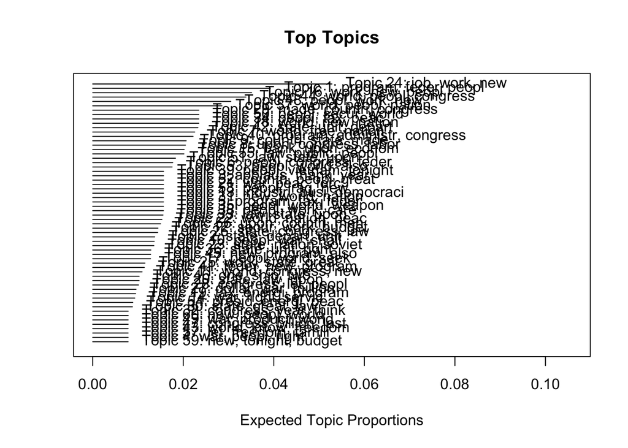

```r
plot(sotu_topic_60)
```

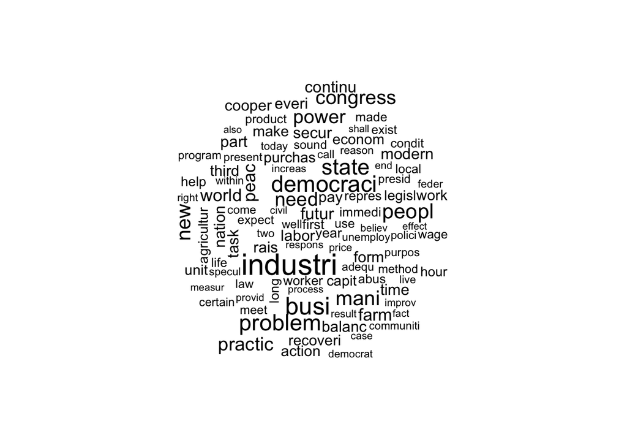

```r
cloud(sotu_topic_60, topic=13, scale=c(2,.25))
```

```r
sotu_topic_60_effects <- estimateEffect(1:20 ~ party + s(year), sotu_topic_60, meta = sotu_data_prepd$meta, uncertainty = "Global")
summary(sotu_topic_60_effects, topics=3)
```

```
##
## Call:
## estimateEffect(formula = 1:20 ~ party + s(year), stmobj = sotu_topic_60,
##     metadata = sotu_data_prepd$meta, uncertainty = "Global")
##
##
## Topic 3:
##
## Coefficients:
##                  Estimate Std. Error t value Pr(>|t|)
## (Intercept)     -0.002144   0.049058  -0.044    0.965
## partyRepublican  0.002906   0.013156   0.221    0.826
## s(year)1        -0.004459   0.088272  -0.051    0.960
## s(year)2         0.008981   0.062024   0.145    0.885
## s(year)3        -0.009920   0.069587  -0.143    0.887
## s(year)4         0.017119   0.060495   0.283    0.778
## s(year)5        -0.025249   0.061563  -0.410    0.682
## s(year)6         0.048999   0.059001   0.830    0.408
## s(year)7        -0.093920   0.064230  -1.462    0.146
## s(year)8         0.234975   0.074312   3.162    0.002 **
## s(year)9        -0.417686   0.078084  -5.349  4.5e-07 ***
## s(year)10        0.823774   0.080611  10.219  < 2e-16 ***
## ---
## Signif. codes:  0 '***' 0.001 '**' 0.01 '*' 0.05 '.' 0.1 ' ' 1
```

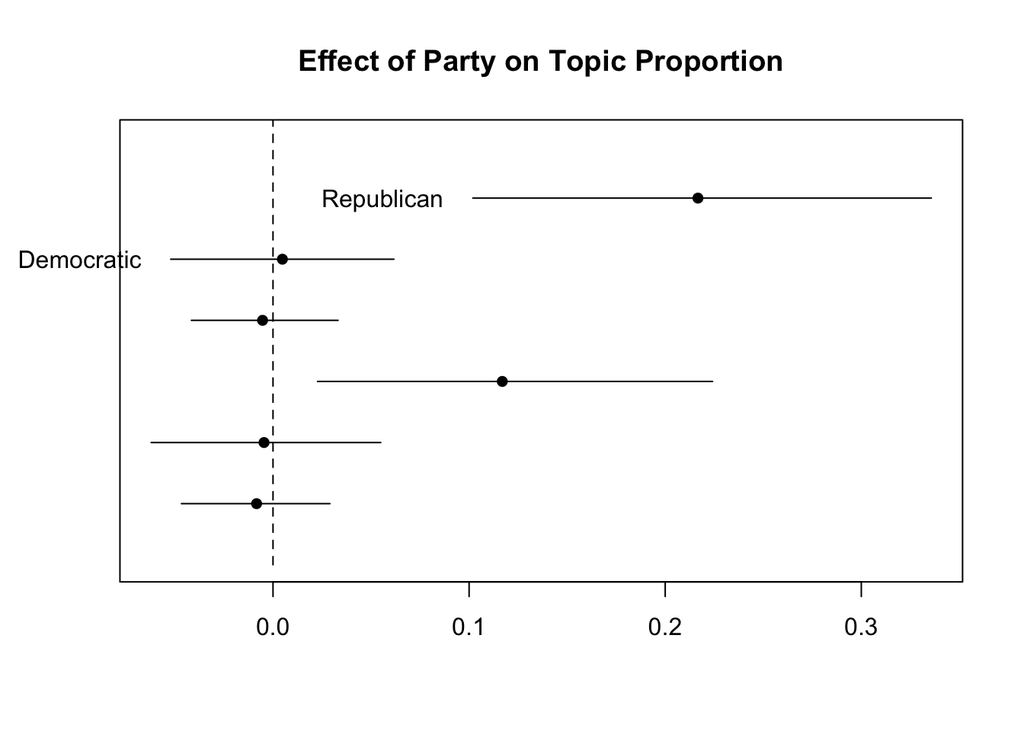

```r
plot(sotu_topic_60_effects, covariate = "party", topics = c(1:3), model = sotu_topic_60, method = "pointestimate",
     main = "Effect of Party on Topic Proportion", labeltype = "custom",
     custom.labels = c("Republican", "Democratic")
     )
```

# Content difference

```r
sotu_topic_5 <- stm(documents = sotu_data_prepd$documents,
                    vocab = sotu_data_prepd$vocab,
                    K = 5,
                    prevalence = ~party,
                     content =~ party,
                     max.em.its = 75,
                     data = sotu_data_prepd$meta,
                     init.type = "Spectral",
                     verbose=TRUE
)
```

```
## Beginning Spectral Initialization
##   Calculating the gram matrix...
##   Finding anchor words...
##      .....
##   Recovering initialization...
##      ................................................................................
## Initialization complete.
## ................................................................................................................................
## Completed E-Step (0 seconds).
## ....................................................................................................
## Completed M-Step (7 seconds).
## Completing Iteration 1 (approx. per word bound = -7.401)
## ................................................................................................................................
## Completed E-Step (0 seconds).
## ....................................................................................................
## Completed M-Step (7 seconds).
## Completing Iteration 2 (approx. per word bound = -7.250, relative change = 2.043e-02)
## ................................................................................................................................
## Completed E-Step (0 seconds).
## ....................................................................................................
## Completed M-Step (7 seconds).
## Completing Iteration 3 (approx. per word bound = -7.237, relative change = 1.661e-03)
## ................................................................................................................................
## Completed E-Step (0 seconds).
## ....................................................................................................
## Completed M-Step (7 seconds).
## Completing Iteration 4 (approx. per word bound = -7.234, relative change = 4.613e-04)
## ................................................................................................................................
## Completed E-Step (0 seconds).
## ....................................................................................................
## Completed M-Step (7 seconds).
## Completing Iteration 5 (approx. per word bound = -7.233, relative change = 1.941e-04)
## Topic 1: seaway, hydroelectr, lao, redevelop, wartim
##  Topic 2: battleship, porto, cultiv, hitherto, auxiliari
##  Topic 3: kid, didnt, math, isnt, qaida
##  Topic 4: rocket, loos, spell, world-wid, indomit
##  Topic 5: decontrol, housejanuari, shelf, windfal, ceta
## Aspect 1: well-equip, oak, outlet, malign, collabor
##  Aspect 2: resurg, film, ballist, mileston, reliabl
## ................................................................................................................................
```

[output cut: 132 more lines]

```
## ................................................................................................................................
## Completed E-Step (0 seconds).
## ....................................................................................................
## Completed M-Step (7 seconds).
## Completing Iteration 27 (approx. per word bound = -7.217, relative change = 3.053e-05)
## ................................................................................................................................
## Completed E-Step (0 seconds).
## ....................................................................................................
## Completed M-Step (7 seconds).
## Completing Iteration 28 (approx. per word bound = -7.217, relative change = 2.058e-05)
## ................................................................................................................................
## Completed E-Step (0 seconds).
## ....................................................................................................
## Completed M-Step (7 seconds).
## Model Converged
```

# Text scaling

From https://burtmonroe.github.io/TextAsDataCourse/Tutorials/IntroductionToWordfish.nb.html

```r
# Irish budget speeches from 2010

toks_irish <- tokens(data_corpus_irishbudget2010, remove_punct = TRUE)
dfmat_irish <- dfm(toks_irish)
tmod_wf <- textmodel_wordfish(dfmat_irish, dir = c(2, 4))
summary(tmod_wf)
```

```
##
## Call:
## textmodel_wordfish.dfm(x = dfmat_irish, dir = c(2, 4))
##
## Estimated Document Positions:
##                              theta      se
## Lenihan, Brian (FF)        1.79395 0.02007
## Bruton, Richard (FG)      -0.62137 0.02824
## Burton, Joan (LAB)        -1.13501 0.01568
## Morgan, Arthur (SF)       -0.07840 0.02896
## Cowen, Brian (FF)          1.77839 0.02330
## Kenny, Enda (FG)          -0.75343 0.02635
## ODonnell, Kieran (FG)     -0.47615 0.04309
## Gilmore, Eamon (LAB)      -0.58474 0.02992
## Higgins, Michael (LAB)    -1.00390 0.03964
## Quinn, Ruairi (LAB)       -0.92648 0.04183
## Gormley, John (Green)      1.18354 0.07224
## Ryan, Eamon (Green)        0.14816 0.06322
## Cuffe, Ciaran (Green)      0.71537 0.07291
## OCaolain, Caoimhghin (SF) -0.03993 0.03877
##
## Estimated Feature Scores:
##         when      i presented    the supplementary  budget     to   this  house
## beta -0.1593 0.3179    0.3604 0.1934         1.077 0.03546 0.3078 0.2474 0.1399
## psi   1.6241 2.7239   -1.7958 5.3308        -1.134 2.70992 4.5190 3.4603 1.0396
##        last   april    said     we   could   work    our    way through  period
## beta 0.2420 -0.1563 -0.8339 0.4158 -0.6138 0.5223 0.6894 0.2751  0.6116  0.4986
## psi  0.9853 -0.5725 -0.4515 3.5124  1.0857 1.1151 2.5277 1.4190  1.1604 -0.1779
##          of severe economic distress   today    can  report   that
## beta 0.2778  1.229   0.4238    1.799 0.09153 0.3041  0.6199 0.0152
## psi  4.4656 -2.013   1.5714   -4.456 0.83874 1.5644 -0.2467 3.8379
##      notwithstanding difficulties   past
## beta           1.799        1.175 0.4747
## psi           -4.456       -1.357 0.9321
```

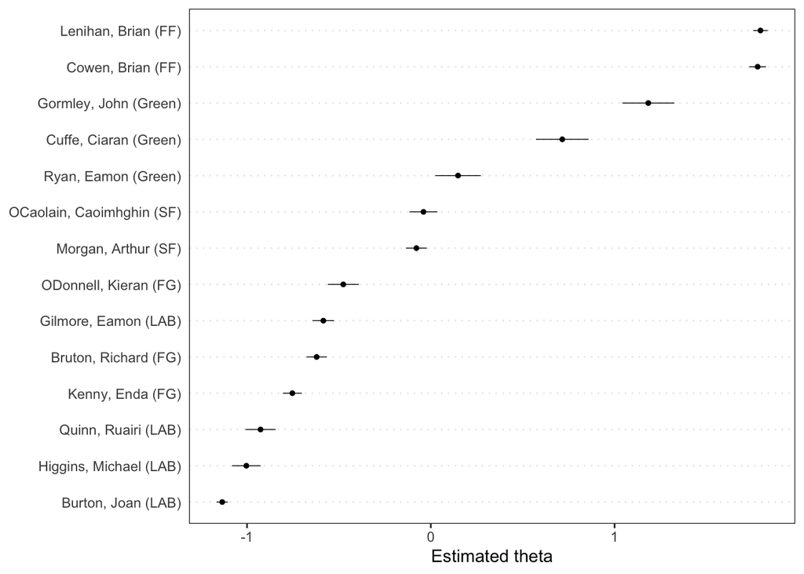

```r
textplot_scale1d(tmod_wf)
```

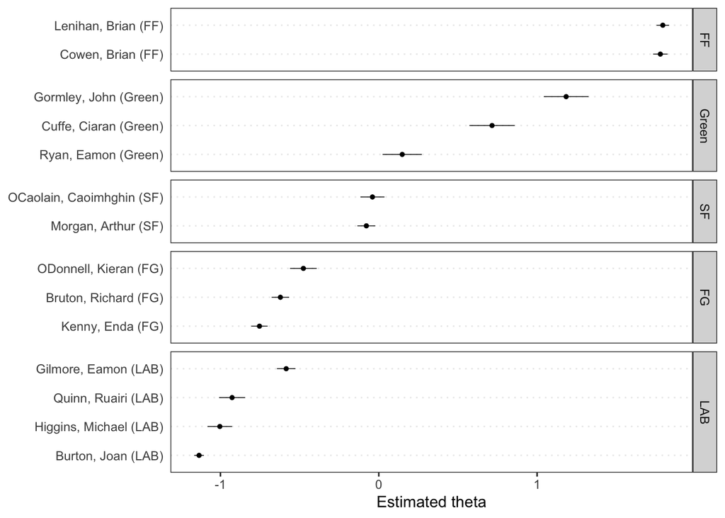

```r
textplot_scale1d(tmod_wf, groups = dfmat_irish$party)
```

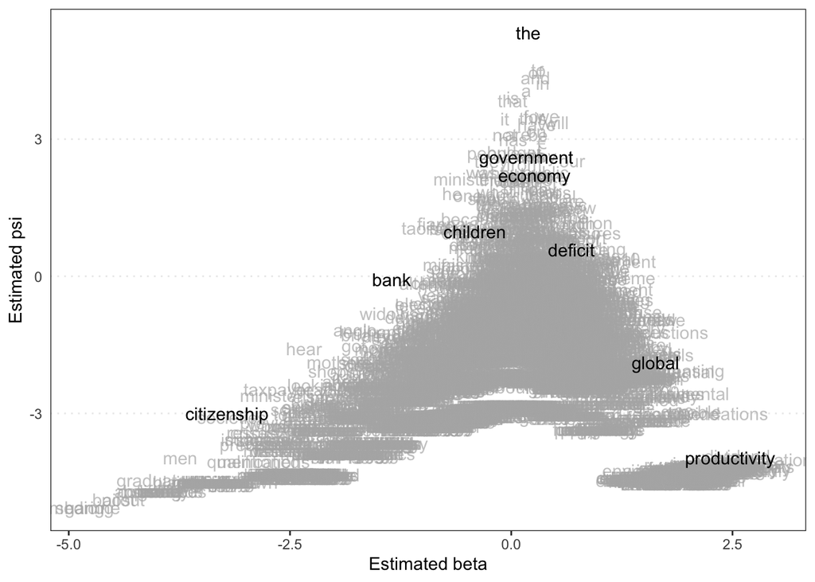

```r
textplot_scale1d(tmod_wf, margin = "features",
                 highlighted = c("government", "global", "children",
                                 "bank", "economy", "the", "citizenship",
                                 "productivity", "deficit"))
```

Topic models can also do unidimensional scaling!

```r
dfmat_irish_stm <- quanteda::convert(dfmat_irish, to = "stm")
names(dfmat_irish_stm)
```

```
## [1] "documents" "vocab"     "meta"
```

```r
irish_stmfit <- stm(documents = dfmat_irish_stm$documents,
                     vocab = dfmat_irish_stm$vocab,
                     K = 2,
                     max.em.its = 75,
                     data = dfmat_irish_stm$meta,
                     init.type = "Spectral"
)
```

```
## Beginning Spectral Initialization
##   Calculating the gram matrix...
##   Finding anchor words...
##      ..
##   Recovering initialization...
##      ...................................................
## Initialization complete.
## ..............
## Completed E-Step (0 seconds).
## Completed M-Step.
## Completing Iteration 1 (approx. per word bound = -6.311)
## ..............
## Completed E-Step (0 seconds).
## Completed M-Step.
## Completing Iteration 2 (approx. per word bound = -6.245, relative change = 1.036e-02)
## ..............
## Completed E-Step (0 seconds).
## Completed M-Step.
## Completing Iteration 3 (approx. per word bound = -6.235, relative change = 1.568e-03)
## ..............
## Completed E-Step (0 seconds).
## Completed M-Step.
## Completing Iteration 4 (approx. per word bound = -6.235, relative change = 9.442e-05)
## ..............
## Completed E-Step (0 seconds).
## Completed M-Step.
## Completing Iteration 5 (approx. per word bound = -6.235, relative change = 4.480e-05)
## Topic 1: the, of, to, and, in
##  Topic 2: the, to, of, and, in
## ..............
## Completed E-Step (0 seconds).
## Completed M-Step.
## Completing Iteration 6 (approx. per word bound = -6.234, relative change = 3.591e-05)
## ..............
## Completed E-Step (0 seconds).
## Completed M-Step.
## Completing Iteration 7 (approx. per word bound = -6.234, relative change = 2.953e-05)
## ..............
## Completed E-Step (0 seconds).
## Completed M-Step.
```

[output cut: 12 more lines]

```
## Completed E-Step (0 seconds).
## Completed M-Step.
## Completing Iteration 11 (approx. per word bound = -6.234, relative change = 1.332e-05)
## ..............
## Completed E-Step (0 seconds).
## Completed M-Step.
## Completing Iteration 12 (approx. per word bound = -6.234, relative change = 1.170e-05)
## ..............
## Completed E-Step (0 seconds).
## Completed M-Step.
## Completing Iteration 13 (approx. per word bound = -6.234, relative change = 1.081e-05)
## ..............
## Completed E-Step (0 seconds).
## Completed M-Step.
## Model Converged
```

```r
compare.df <- cbind(name=rownames(docvars(dfmat_irish)),wordfish = tmod_wf$theta, stm = irish_stmfit$theta[,2])
compare.df
```

```
##       name wordfish              stm
##  [1,] "1"  "1.7939525940103"     "0.999856413780379"
##  [2,] "2"  "-0.621368407902863"  "0.774604594044597"
##  [3,] "3"  "-1.13501126312838"   "0.000209926082396561"
##  [4,] "4"  "-0.0784035441263323" "0.000345705990393679"
##  [5,] "5"  "1.77839279585767"    "0.9998131172257"
##  [6,] "6"  "-0.753426375315632"  "0.000319302879177373"
##  [7,] "7"  "-0.47615363594704"   "0.000792269895033178"
##  [8,] "8"  "-0.584743107956522"  "0.000582960655753373"
##  [9,] "9"  "-1.00389867131573"   "0.470666141616242"
## [10,] "10" "-0.926483567016401"  "0.489043184909732"
## [11,] "11" "1.18354437979617"    "0.997922283827153"
## [12,] "12" "0.148159273451941"   "0.996624540457028"
## [13,] "13" "0.715368140729654"   "0.998058889709461"
## [14,] "14" "-0.0399286111368369" "0.000426769783914437"
```